# Untitled

Joaquin Arango

12/29/2020

## Introduction/Background

Using devices such as Jawbone Up, Nike FuelBand, and Fitbit it is now possible to collect a large amount of data about personal activity relatively inexpensively. These type of devices are part of the quantified self movement – a group of enthusiasts who take measurements about themselves regularly to improve their health, to find patterns in their behavior, or because they are tech geeks. One thing that people regularly do is quantify how much of a particular activity they do, but they rarely quantify how well they do it. In this project, your goal will be to use data from accelerometers on the belt, forearm, arm, and dumbell of 6 participants. They were asked to perform barbell lifts correctly and incorrectly in 5 different ways. More information is available from the website here: http://web.archive.org/web/20161224072740/http:/groupware.les.inf.puc-rio.br/har (see the section on the Weight Lifting Exercise Dataset).

## Datasets

The training data for this project are available here:

https://d396qusza40orc.cloudfront.net/predmachlearn/pml-training.csv

The test data are available here:

https://d396qusza40orc.cloudfront.net/predmachlearn/pml-testing.csv

The data for this project come from this source: http://web.archive.org/web/20161224072740/http:/groupware.les.inf.puc-rio.br/har. If you use the document you create for this class for any purpose please cite them as they have been very generous in allowing their data to be used for this kind of assignment.

## Preparing Data

Set the environment and download the training data and the test data.

```r
library(caret)
```

```r
library(rpart)
library(rpart.plot)
library(RColorBrewer)
library(RGtk2)
library(rattle)
library(randomForest)
library(gbm)
training_data <- read.csv('C:/Users/Administrator/Desktop/Practical-Machine-Learning-Week-4-Project/pml-training.csv')
testing_data <-  read.csv('C:/Users/Administrator/Desktop/Practical-Machine-Learning-Week-4-Project/pml-testing.csv')

dim(training_data)
```

```
## [1] 19622   160
```

```r
dim(testing_data)
```

```
## [1]  20 160
```

## Cleaning Data

```r
non_values <- nearZeroVar(training_data)


train_data <- training_data[,-non_values]
test_data <- testing_data[,-non_values]

dim(train_data)
```

```
## [1] 19622   100
```

```r
dim(test_data)
```

```
## [1]  20 100
```

Remove data that contains more than 95% of NA values.

```r
na_col <- sapply(train_data, function(x) mean(is.na(x))) > 0.95

training <- train_data[,na_col == FALSE]
testing <- test_data[,na_col == FALSE]

dim(training)
```

```
## [1] 19622    59
```

```r
dim(testing)
```

```
## [1] 20 59
```

The first 7 variables turn out to be non-numeric.

```r
train <- training[,8:59]
test <- testing[,8:59]

dim(train)
```

```
## [1] 19622    52
```

```r
dim(test)
```

```
## [1] 20 52
```

## Data Partitoning

```r
inTrain <- createDataPartition(train$classe, p=0.7, list=FALSE)
tr <- train[inTrain, ]
te <- train[-inTrain, ]


dim(tr)
```

```
## [1] 13737    52
```

```r
dim(te)
```

```
## [1] 5885   52
```

Now we can make models.

## Decision Tree Model

```r
DTmodel <- train(classe ~ ., method='rpart', data=tr)
```

Prediction of Decision Tree Model

```r
DTprediction <- predict(DTmodel, te)
confusionMatrix(table(te$classe, DTprediction))
```

```
## Confusion Matrix and Statistics
##
##    DTprediction
##        A    B    C    D    E
##   A 1527   27  119    0    1
##   B  489  355  266   29    0
##   C  452   48  526    0    0
##   D  418   19  370  157    0
##   E  263  163  309   48  299
##
## Overall Statistics
##
##                Accuracy : 0.4867
##                  95% CI : (0.4738, 0.4995)
##     No Information Rate : 0.5351
##     P-Value [Acc > NIR] : 1
##
##                   Kappa : 0.3287
##
##  Mcnemar's Test P-Value : <2e-16
##
## Statistics by Class:
##
##                      Class: A Class: B Class: C Class: D Class: E
## Sensitivity            0.4849  0.58007  0.33082  0.67094  0.99667
## Specificity            0.9463  0.85132  0.88359  0.85719  0.85980
## Pos Pred Value         0.9122  0.31168  0.51267  0.16286  0.27634
## Neg Pred Value         0.6148  0.94585  0.78102  0.98435  0.99979
## Prevalence             0.5351  0.10399  0.27018  0.03976  0.05098
## Detection Rate         0.2595  0.06032  0.08938  0.02668  0.05081
## Detection Prevalence   0.2845  0.19354  0.17434  0.16381  0.18386
## Balanced Accuracy      0.7156  0.71569  0.60720  0.76407  0.92823
```

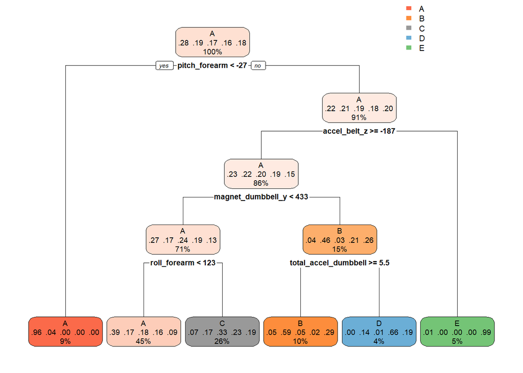

```r
rpart.plot(DTmodel$finalModel, roundint = FALSE)
```

Prediction accuracy is 49%, surely we can do better.

## Random Forest Model

```r
RFmodel <- train(classe ~ ., data = tr, method="rf", ntree= 100)
```

Prediction of Random Forest Model

```r
RFprediction <- predict(RFmodel, te)
RFconMat <- confusionMatrix(table(RFprediction, te$classe))
RFconMat
```

```
## Confusion Matrix and Statistics
##
##
## RFprediction    A    B    C    D    E
##            A 1673    7    0    0    0
##            B    1 1129    6    0    0
##            C    0    3 1018   13    2
##            D    0    0    2  950    2
##            E    0    0    0    1 1078
##
## Overall Statistics
##
##                Accuracy : 0.9937
##                  95% CI : (0.9913, 0.9956)
##     No Information Rate : 0.2845
##     P-Value [Acc > NIR] : < 2.2e-16
##
##                   Kappa : 0.992
##
##  Mcnemar's Test P-Value : NA
##
## Statistics by Class:
##
##                      Class: A Class: B Class: C Class: D Class: E
## Sensitivity            0.9994   0.9912   0.9922   0.9855   0.9963
## Specificity            0.9983   0.9985   0.9963   0.9992   0.9998
## Pos Pred Value         0.9958   0.9938   0.9826   0.9958   0.9991
## Neg Pred Value         0.9998   0.9979   0.9984   0.9972   0.9992
## Prevalence             0.2845   0.1935   0.1743   0.1638   0.1839
## Detection Rate         0.2843   0.1918   0.1730   0.1614   0.1832
## Detection Prevalence   0.2855   0.1930   0.1760   0.1621   0.1833
## Balanced Accuracy      0.9989   0.9949   0.9942   0.9923   0.9980
```

Prediction accuracy is 99%, nice!

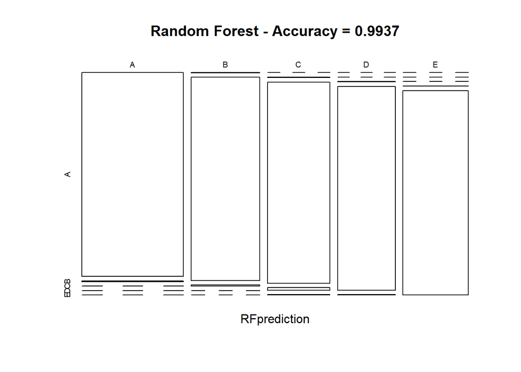

```r
plot(RFconMat$table, col = RFconMat$byClass,
     main=paste("Random Forest - Accuracy =",
                round(RFconMat$overall['Accuracy'], 4)))
```

## Gradient Boosting Model

Random Forest was really good, lets see if the Gradient Boosting Model does even better.

```r
GBMmodel <- train(classe ~ ., data = tr, method="gbm", verbose = FALSE)
GBMmodel$finalModel
```

```
## A gradient boosted model with multinomial loss function.
## 150 iterations were performed.
## There were 51 predictors of which 51 had non-zero influence.
```

Prediction of Gradient Boosting Model

```r
GBMprediction <- predict(GBMmodel, te)
GBMconMat <- confusionMatrix(table(GBMprediction, te$classe))
GBMconMat
```

```
## Confusion Matrix and Statistics
##
##
## GBMprediction    A    B    C    D    E
##             A 1655   40    0    1    4
##             B   15 1066   41    4    6
##             C    1   32  973   38   14
##             D    3    0    9  915   16
##             E    0    1    3    6 1042
##
## Overall Statistics
##
##                Accuracy : 0.9602
##                  95% CI : (0.9549, 0.9651)
##     No Information Rate : 0.2845
##     P-Value [Acc > NIR] : < 2.2e-16
##
##                   Kappa : 0.9497
##
##  Mcnemar's Test P-Value : 2.438e-08
##
## Statistics by Class:
##
##                      Class: A Class: B Class: C Class: D Class: E
## Sensitivity            0.9886   0.9359   0.9483   0.9492   0.9630
## Specificity            0.9893   0.9861   0.9825   0.9943   0.9979
## Pos Pred Value         0.9735   0.9417   0.9197   0.9703   0.9905
## Neg Pred Value         0.9955   0.9846   0.9890   0.9901   0.9917
## Prevalence             0.2845   0.1935   0.1743   0.1638   0.1839
## Detection Rate         0.2812   0.1811   0.1653   0.1555   0.1771
## Detection Prevalence   0.2889   0.1924   0.1798   0.1602   0.1788
## Balanced Accuracy      0.9890   0.9610   0.9654   0.9717   0.9805
```

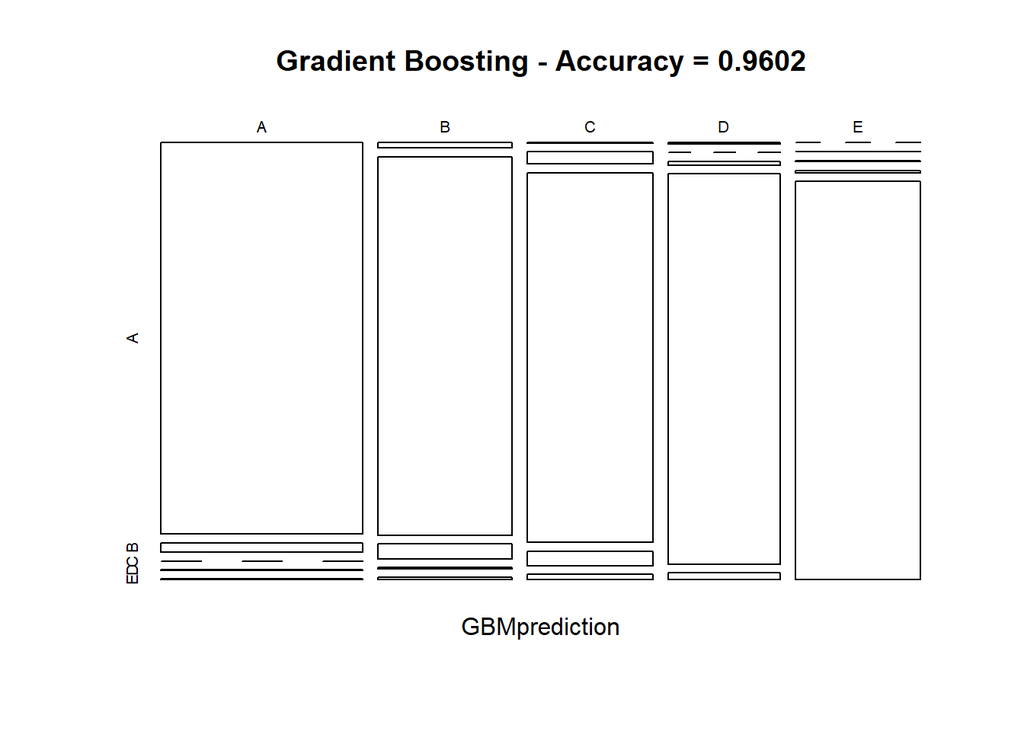

```r
plot(GBMconMat$table, col = GBMconMat$byClass,
     main = paste("Gradient Boosting - Accuracy =",
                  round(GBMconMat$overall['Accuracy'], 4)))
```

Gradient Boost Model has 96% accuracy. Let’s see now each model has predicted the validation dataset. Lets just consider RF and GBM since they clearly did better.

```r
RFconMat$overall
```

```
##       Accuracy          Kappa  AccuracyLower  AccuracyUpper   AccuracyNull
##      0.9937128      0.9920464      0.9913443      0.9955695      0.2844520
## AccuracyPValue  McnemarPValue
##      0.0000000            NaN
```

```r
GBMconMat$overall
```

```
##       Accuracy          Kappa  AccuracyLower  AccuracyUpper   AccuracyNull
##   9.602379e-01   9.496774e-01   9.549273e-01   9.650858e-01   2.844520e-01
## AccuracyPValue  McnemarPValue
##   0.000000e+00   2.437786e-08
```

## Results/Conclusion

Random Forest Model has more accuracy then Gradient Boosting Model, we’ll use the RF model just to get one last prediction from the testing data.

```r
LastRFpred <- predict(RFmodel, test)
LastRFpred
```

```
##  [1] B A B A A E D B A A B C B A E E A B B B
## Levels: A B C D E
```